# Gróðurmælingar

mars 2026

## Um hvað snýst rannsóknin

> Í þessari R-greiningu vinnum við með **167 endurmælda gróðurreiti** á Íslandi,  
> með það að markmiði að meta breytingu í vistfræðilegri samsetningu milli fyrri og seinni mælingar.

### **Hefur gróðurfar breyst?**

Stutta svarið er: **já, og breytingin er nógu samræmd til að mælast skýrt í gögnum.**

## Gagnasafnið í stuttu máli

| Endurmældir reitir | 167 |
| --- | --- |
| Heildarfjöldi tegundaskráninga | 10543 |
| Fjöldi tegunda í gagnasafni | 747 |
| Stysta bil milli mælinga | 9 ár |
| Lengsta bil milli mælinga | 25 ár |
| Miðgildi bils | 12 ár |

Hver reitur er borinn saman við sjálfan sig (fyrri vs seinni mæling).  
Það dregur úr staðbundnum mun milli svæða og eykur skýrleika í tímabreytingu.

## Niðurstaða 1 — Tegundafjöldi hefur færst

Flestir reitir standa ekki í stað.

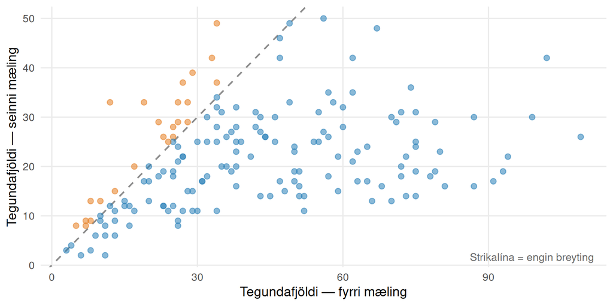

Punktar **fyrir ofan** línu = fleiri tegundir nú. Punktar **fyrir neðan** = færri.

## Niðurstaða 1 — Hversu mikil var breytingin?

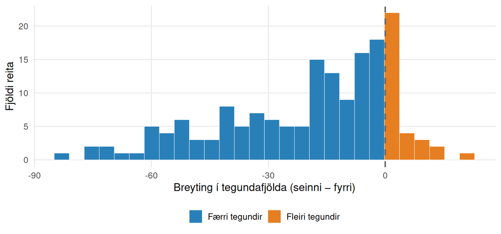

## Niðurstaða 2 — Fjölbreytni (ekki bara fjöldi) hefur líka breyst

Tegundafjöldi telur einungis fjölda tegunda.  
**Shannon-fjölbreytni** tekur einnig tillit til dreifingar þekju milli tegunda.

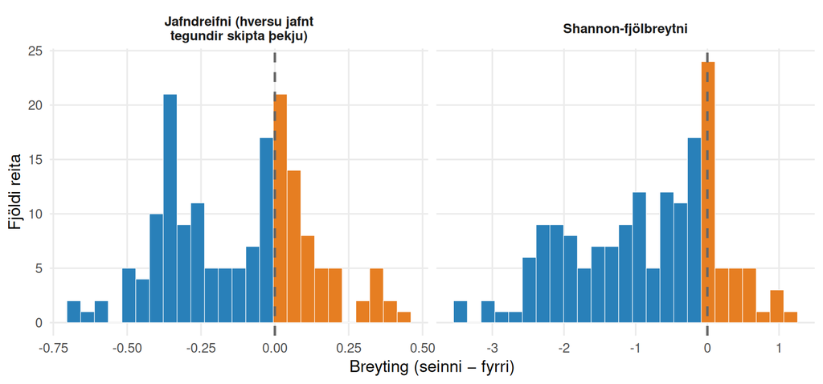

Miðgildi breytingar í Shannon: **-0.656** · miðgildi jafndreifni: **-0.064**

## Niðurstaða 3 — Heildarþekja gróðurs hefur einnig breyst

Ekki bara hvaða tegundir eru til staðar, heldur líka hversu mikil gróðurþekjan er.

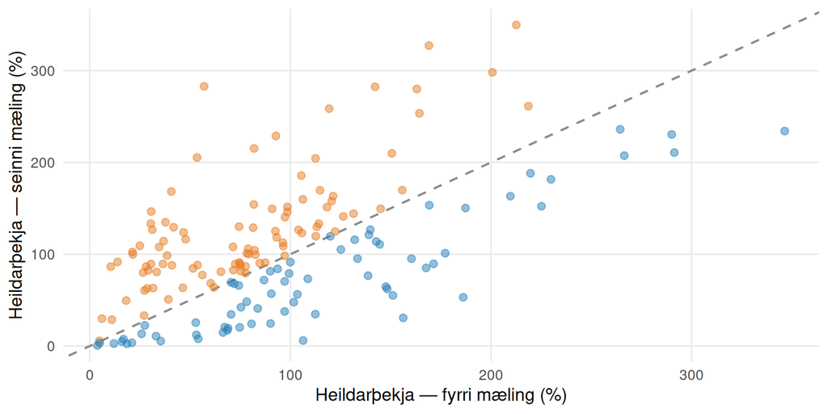

Punktar fyrir ofan línu sýna aukna heildarþekju.

## Niðurstaða 4 — Ríkjandi tegundir eru ekki þær sömu

Tegundir sem voru ríkjandi í fyrri mælingu eru oft ekki þær sömu og ríkja í seinni mælingu.

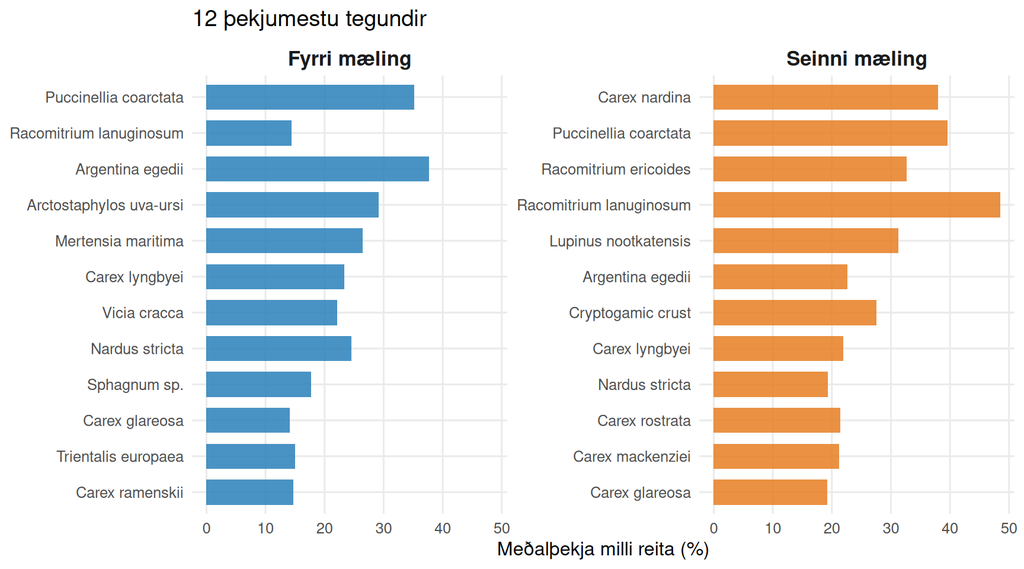

## Niðurstaða 5 — Samsetning samfélaga hefur færst

Bray-Curtis mælir ólíkindi í tegundasamsetningu milli fyrri og seinni mælingar.  
**0 = eins samfélag. 1 = engar sameiginlegar tegundir.**

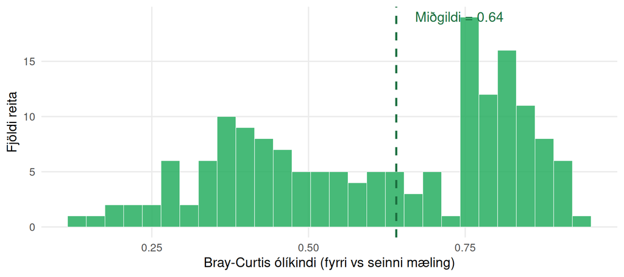

Miðgildi **0.64** bendir til þess að dæmigerður reitur hafi breyst umtalsvert.

## Niðurstaða 6 — Breyting í samfélagssamsetningu er tölfræðilega raunveruleg

Prófað var hvort munur milli fyrri og seinni mælingar væri meiri en búast mætti við af tilviljun,  
með tilliti til þess að hver reitur er pöruð eining.

| Próf | R² | F | p-gildi |
| --- | --- | --- | --- |
| Pöruð PERMANOVA (999 umraðanir) | 0.027 | 8.78 | 0.001 |

> **Í stuttu máli:** Munurinn milli fyrri og seinni mælingar er raunverulegur, ekki slembisveifla.  
> Skýringarhlutfallið er hóflegt (R² = 2.7%) en mynstrið er samræmt milli reita.

## Niðurstaða 7 — Hvaða umhverfisþættir tengjast mynstrinu mest?

| Breyta | r² | p |  | Tegund |
| --- | --- | --- | --- | --- |
| háplöntuþekja | 0.577 | 0.001 | ** | samfelld |
| soil_depth | 0.365 | 0.001 | ** | samfelld |
| total_cover | 0.372 | 0.001 | ** | samfelld |
| vegetation_height_1 | 0.561 | 0.001 | ** | samfelld |
| soil_type_name | 0.329 | 0.001 | ** | flokkabreytur |
| moisture_name | 0.263 | 0.001 | ** | flokkabreytur |
| permafrost | 0.018 | 0.007 | ** | flokkabreytur |
| topography_name | 0.014 | 0.207 | ns | flokkabreytur |

Sterkustu tengingarnar eru við **háplöntuþekju** og **gróðurhæð**.

## Niðurstaða 7 — Hnitunarkort (ordination)

Hver punktur er ein mæling í einum reit. Línur tengja **sama reit** milli fyrri og seinni mælingar.  
Örvar sýna stefnu hækkandi gilda umhverfisbreyta.

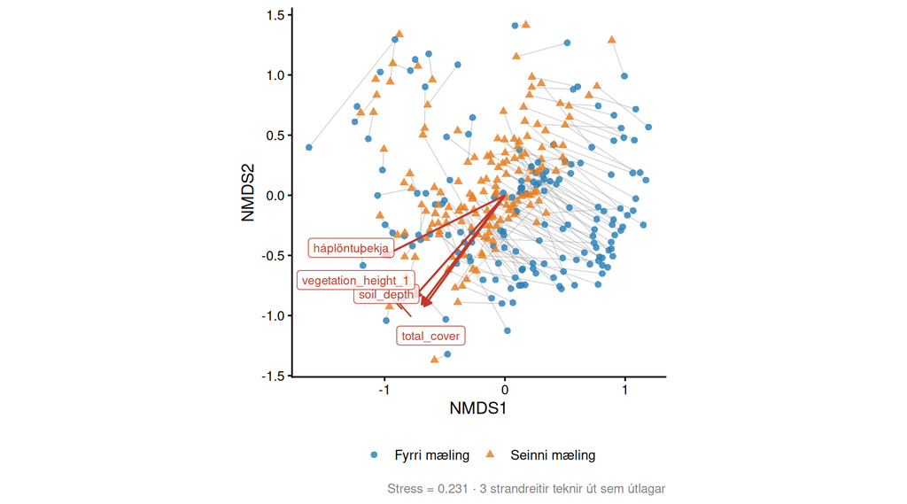

## Niðurstaða 8 — Ákveðnar tegundir tengjast breytingu

**IndVal-greining** finnur tegundir sem tengjast markvisst annaðhvort fyrri eða seinni mælingu.

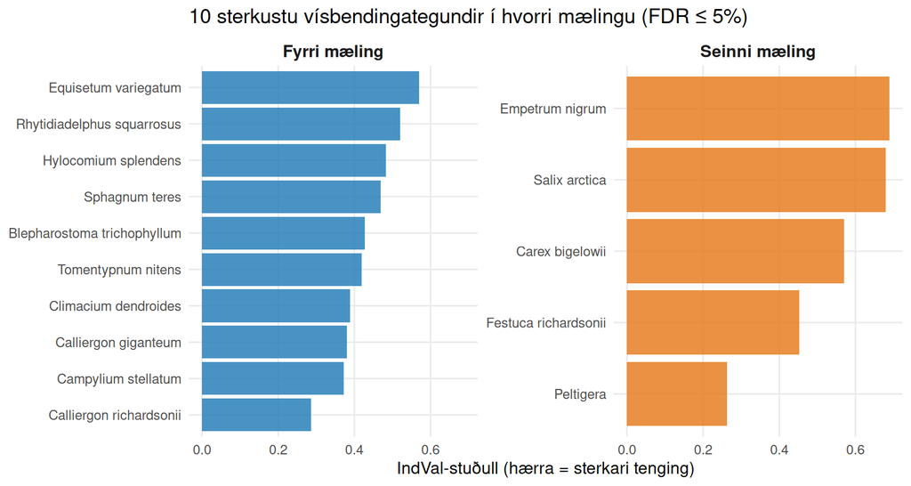

## Hvað virðist knýja breytingarnar?

Út frá þessum gögnum ein og sér er ekki hægt að staðfesta orsakir.  
En mynstrið er samræmt við:

- **Aukna hæð og þéttleika gróðurs** í mörgum reitum  
  (háplöntuþekja og gróðurhæð hafa sterkustu tengslin).
- **Áhrif vistgerðar** — jarðvegstegund og raki skipta máli.
- **Sérstöðu strand-/sandreita** — þeir mynda aðskilið mynstur í hnitun.

> Niðurstöðurnar eru fylgnitengdar. Markviss endurmæling með samhliða loftslags- og landnýtingargögnum  
> myndi gera kleift að svara betur *hvers vegna* samfélögin eru að færast.

## Samantekt

| Niðurstaða | Túlkun |
| --- | --- |
| Tegundafjöldi | 14% reita jukust, 81% drógust saman |
| Shannon-fjölbreytni | Miðgildi breytingar = -0.656 (blönduð stefna) |
| Heildarþekja gróðurs | Margar stöðvar sýna aukna þekju, sumar minnkun |
| Ríkjandi tegundir | 12 þekjumestu tegundir eru að verulegu leyti aðrar |
| Tegundasamsetning | Miðgildi Bray-Curtis = 0.64 |
| Tölfræðilegt öryggi | PERMANOVA p = 0.001, R² = 2.7% |

> **Kjarnaniðurstaða:** Gróðurreitir á Íslandi hafa færst milli mælinga á mælanlegan og samræmdan hátt,  
> og breytingin skýrist ekki af tilviljun einni.

## Næstu skref

**Til skemmri tíma — hámarka upplýsingagildi núverandi gagnasafns**

- Setja bil milli mælinga (`gap_years`) inn sem skýribreytu
- Keyra lagskiptar greiningar eftir jarðvegsgerð/vistgerð
- Meta landfræðilega klösun breytinga (rúmgreining)

**Til lengri tíma — ef ný vettvangsgögn fást**

- Endurmæla valda reiti með stöðluðu verklagi
- Safna samhliða loftslags- og landnýtingarbreytum
- Færa greiningu frá „hefur breyst?“ yfir í „hvers vegna breytist?“

## Aðferðir í stuttu máli

| Skref | Lýsing |
| --- | --- |
| Gögn | `v_plants_allt.csv` · 167 endurmældir reitir |
| Þekjusamhæfing | Braun-Blanquet flokkar → miðgildi; tölugildi notuð beint |
| Pöruð hönnun | Hver reitur borinn saman við sjálfan sig (fyrri vs seinni mæling) |
| Fjölbreytni | Tegundafjöldi S, Shannon H, Simpson D, Pielou J |
| Samsetning | Bray-Curtis ólíkindi, NMDS (k=2), pöruð PERMANOVA |
| Umhverfisvörpun | `vegan::envfit` á ströngu breytusetti |
| Vísbendingategundir | `indicspecies::multipatt` IndVal.g, BH-leiðrétt FDR |
| Útlagar | RN-02, RN-03, RN-65-01 teknir út úr NMDS (strandsandar) |
| Hugbúnaður | R · tidyverse · vegan · indicspecies |

## Um hvað snýst rannsóknin

Í þessari greiningu er unnið með gögn úr **167 endurmældum gróðurreitum** á Íslandi.  
Úrvinnslan byggir á pöruðum samanburði þar sem fyrir hvern reit er fyrri og síðari mæling borin saman.

### Spurning

**Hefur gróðurinn breyst á milli mælinga?**

## Gögnin í stuttu máli

| Atriði | Gildi |
| --- | --- |
| Endurmældir reitir | 167 |
| Heildarfjöldi tegundaskráninga | 10543 |
| Einstakar plöntutegundir | 747 |
| Stysta bil milli mælinga | 9 ár |
| Lengsta bil milli mælinga | 25 ár |
| Miðgildi bils | 12 ár |

## Niðurstaða 1 — Tegundafjöldi hefur breyst

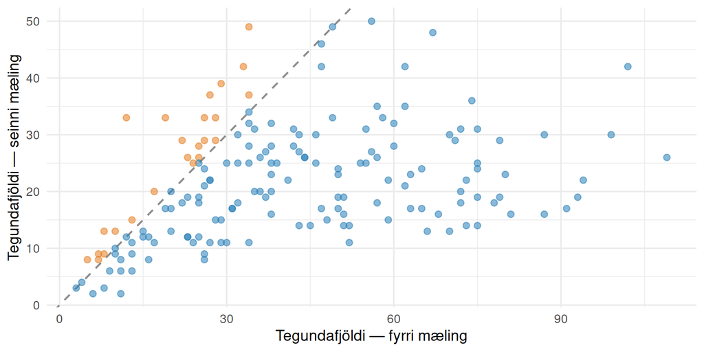

Punktar **fyrir ofan** línu = fleiri tegundir í seinni mælingu. Punktar **fyrir neðan** línu færri tegundir í seinni mælingu.

## Niðurstaða 2 — Gróðursamfélögin sjálf hafa færst

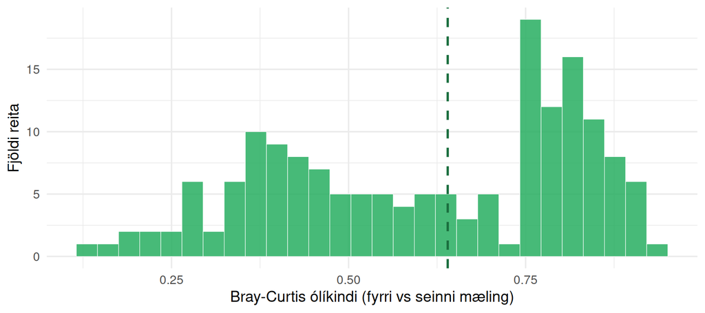

Miðgildi Bray-Curtis er **0.64** — sem bendir til verulegrar breytingar í mörgum reitum.

## Niðurstaða 3 — Breytingin er tölfræðilega marktæk

| Prófun | R² | F | p-gildi |
| --- | --- | --- | --- |
| Pöruð PERMANOVA (999 umraðanir) | 0.027 | 8.78 | 0.001 |

**Túlkun:** Fyrri og seinni mæling eru ekki aðeins mismunandi vegna tilviljunar.

## Niðurstaða 4 — Hvaða umhverfisþættir tengjast mynstrinu?

| Breyta | r² | p | Tegund |
| --- | --- | --- | --- |
| háplöntuþekja | 0.577 | 0.001 | samfelld |
| soil_depth | 0.365 | 0.001 | samfelld |
| total_cover | 0.372 | 0.001 | samfelld |
| vegetation_height_1 | 0.561 | 0.001 | samfelld |
| soil_type_name | 0.329 | 0.001 | flokkabreytur |
| moisture_name | 0.263 | 0.001 | flokkabreytur |
| permafrost | 0.018 | 0.007 | flokkabreytur |
| topography_name | 0.014 | 0.207 | flokkabreytur |

Sterkustu tengingarnar eru við **háplöntuþekju** og **gróðurhæð**.

## NMDS kort (án 3 strand-útlaga)

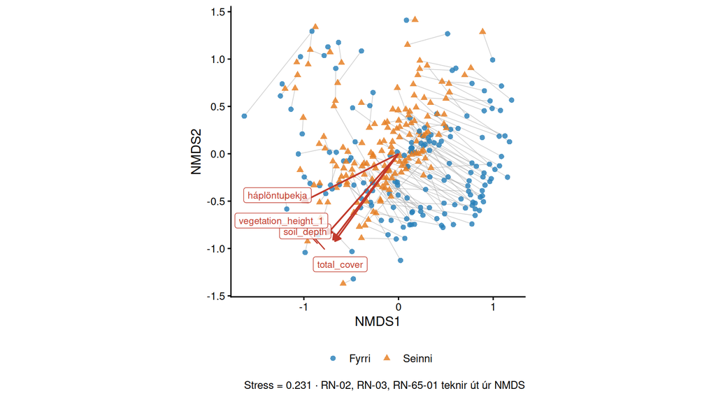

## Samantekt

| Niðurstaða | Túlkun |
| --- | --- |
| Tegundafjöldi | 14% reita með aukningu, 81% með minnkun |
| Shannon fjölbreytni | Miðgildi breytingar = -0.656 |
| Heildarþekja | Margar stöðvar sýna breytingu í heildarþekju |
| Ríkjandi tegundir | Ríkjandi tegundir eru oft aðrar en áður |
| Samsetning samfélaga | Miðgildi Bray-Curtis = 0.64 |
| Tölfræðilegt öryggi | PERMANOVA p = 0.001, R² = 2.7% |

## Aðferðir í stuttu máli

| Skref | Lýsing |
| --- | --- |
| Gögn | `v_plants_allt.csv` · 167 endurmældir reitir |
| Þekjusamhæfing | Braun-Blanquet flokkar → miðgildi; tölugildi notuð beint |
| Pöruð hönnun | Hver reitur borinn saman við sjálfan sig (fyrsta vs síðasta mæling) |
| Fjölbreytni | Tegundafjöldi S, Shannon H, Simpson D, Pielou J |
| Samsetning | Bray-Curtis, NMDS (k=2), pöruð PERMANOVA |
| Umhverfisaðhvarf | `vegan::envfit` á ströngu breytusetti |
| Vísbendingategundir | `indicspecies::multipatt` IndVal.g, BH-leiðrétting |
| Útlagar | RN-02, RN-03, RN-65-01 teknir út úr NMDS (strandsamfélög) |
| Hugbúnaður | R · tidyverse · vegan · indicspecies |